# Damages related with Storms and other severe weather events

Esteban R. Freyre

10/17/2019

### Synopsis

Storms and other severe weather events can cause both public health and economic problems for communities and municipalities. Many severe events can result in fatalities, injuries, and property damage, and preventing such outcomes to the extent possible is a key concern.

This project involves exploring the U.S. National Oceanic and Atmospheric Administration’s (NOAA) storm database. This database tracks characteristics of major storms and weather events in the United States, including when and where they occur, as well as estimates of any fatalities, injuries, and property damage.

### Assignment

The basic goal of this assignment is to explore the NOAA Storm Database and answer some basic questions about severe weather events. You must use the database to answer the questions below and show the code for your entire analysis. Your analysis can consist of tables, figures, or other summaries. You may use any R package you want to support your analysis.

Consider writing your report as if it were to be read by a government or municipal manager who might be responsible for preparing for severe weather events and will need to prioritize resources for different types of events. However, there is no need to make any specific recommendations in your report.

### Data Processing

Since the size of the data is quite big the data.table package is used for faster and better efficiency reading

```r
library(data.table)
```

The data for this assignment comes in the form of a comma-separated-value file compressed via the bzip2 algorithm to reduce its size. You can download the file from the course web site:

```
Storm Data [47Mb]
```

There is also some documentation of the database available. Here you will find how some of the variables are constructed/defined.

```
National Weather Service Storm Data Documentation
National Climatic Data Center Storm Events FAQ
```

The events in the database start in the year 1950 and end in November 2011. In the earlier years of the database there are generally fewer events recorded, most likely due to a lack of good records. More recent years should be considered more complete.

For sake of better columns class settings we define column classes when loading raw data.

```r
colClasses=c("factor","character","character","character","numeric","character","factor","factor","numeric","character","character","character","character","character","character","numeric","character","character","numeric","numeric","factor","factor","numeric","numeric","numeric","character","numeric","character","character","character","character","numeric","numeric","numeric","numeric","character","numeric")
DT<-fread("repdata_data_StormData.csv",sep = ",",header = TRUE,colClasses=colClasses,na.strings=NULL,data.table=TRUE,nThread=4,keepLeadingZeros=TRUE)
```

data summary

```r
str(DT)
```

```
## Classes 'data.table' and 'data.frame':   902297 obs. of  37 variables:
##  $ STATE__   : Factor w/ 70 levels "1.00","10.00",..: 1 1 1 1 1 1 1 1 1 1 ...
##  $ BGN_DATE  : chr  "4/18/1950 0:00:00" "4/18/1950 0:00:00" "2/20/1951 0:00:00" "6/8/1951 0:00:00" ...
##  $ BGN_TIME  : chr  "0130" "0145" "1600" "0900" ...
##  $ TIME_ZONE : chr  "CST" "CST" "CST" "CST" ...
##  $ COUNTY    : num  97 3 57 89 43 77 9 123 125 57 ...
##  $ COUNTYNAME: chr  "MOBILE" "BALDWIN" "FAYETTE" "MADISON" ...
##  $ STATE     : Factor w/ 72 levels "AK","AL","AM",..: 2 2 2 2 2 2 2 2 2 2 ...
##  $ EVTYPE    : Factor w/ 985 levels "   HIGH SURF ADVISORY",..: 826 826 826 826 826 826 826 826 826 826 ...
##  $ BGN_RANGE : num  0 0 0 0 0 0 0 0 0 0 ...
##  $ BGN_AZI   : chr  "" "" "" "" ...
##  $ BGN_LOCATI: chr  "" "" "" "" ...
##  $ END_DATE  : chr  "" "" "" "" ...
##  $ END_TIME  : chr  "" "" "" "" ...
##  $ COUNTY_END: chr  "0.00" "0.00" "0.00" "0.00" ...
```

[output cut: 24 more lines]

Let’s see first rows of the data table

```r
head(DT)
```

```
##    STATE__           BGN_DATE BGN_TIME TIME_ZONE COUNTY COUNTYNAME STATE
## 1:    1.00  4/18/1950 0:00:00     0130       CST     97     MOBILE    AL
## 2:    1.00  4/18/1950 0:00:00     0145       CST      3    BALDWIN    AL
## 3:    1.00  2/20/1951 0:00:00     1600       CST     57    FAYETTE    AL
## 4:    1.00   6/8/1951 0:00:00     0900       CST     89    MADISON    AL
## 5:    1.00 11/15/1951 0:00:00     1500       CST     43    CULLMAN    AL
## 6:    1.00 11/15/1951 0:00:00     2000       CST     77 LAUDERDALE    AL
##     EVTYPE BGN_RANGE BGN_AZI BGN_LOCATI END_DATE END_TIME COUNTY_END
## 1: TORNADO         0                                            0.00
## 2: TORNADO         0                                            0.00
## 3: TORNADO         0                                            0.00
## 4: TORNADO         0                                            0.00
## 5: TORNADO         0                                            0.00
## 6: TORNADO         0                                            0.00
##    COUNTYENDN END_RANGE END_AZI END_LOCATI LENGTH WIDTH F  MAG FATALITIES
```

[output cut: 20 more lines]

We need to solve some problems with Begin date column thus packages for handling date and time classes are loaded

```r
library(lubridate)
library(reshape2)
```

```r
DT[,BGN_DATE:=mdy(colsplit(string=DT$BGN_DATE, pattern=" ",names = c("Part1", "Part2"))$Part1)]
```

Check data problems are solved

```r
head(DT[,BGN_DATE])
```

```
## [1] "1950-04-18" "1950-04-18" "1951-02-20" "1951-06-08" "1951-11-15"
## [6] "1951-11-15"
```

```r
summary(DT$BGN_DATE)
```

```
##         Min.      1st Qu.       Median         Mean      3rd Qu.
## "1950-01-03" "1995-04-20" "2002-03-18" "1998-12-27" "2007-07-28"
##         Max.
## "2011-11-30"
```

Remove not used columns so that the file size is more handy for computations

```r
DT[,c("STATE__","BGN_TIME","TIME_ZONE","COUNTY","COUNTYNAME","BGN_RANGE","BGN_AZI","BGN_LOCATI","END_DATE","END_TIME","COUNTY_END","COUNTYENDN","END_RANGE","END_AZI","END_LOCATI","PROPDMGEXP","CROPDMGEXP","WFO","STATEOFFIC","ZONENAMES","LATITUDE","LONGITUDE","LATITUDE_E","LONGITUDE_","REMARKS","REFNUM"):=NULL]
str(DT)
```

```
## Classes 'data.table' and 'data.frame':   902297 obs. of  11 variables:
##  $ BGN_DATE  : Date, format: "1950-04-18" "1950-04-18" ...
##  $ STATE     : Factor w/ 72 levels "AK","AL","AM",..: 2 2 2 2 2 2 2 2 2 2 ...
##  $ EVTYPE    : Factor w/ 985 levels "   HIGH SURF ADVISORY",..: 826 826 826 826 826 826 826 826 826 826 ...
##  $ LENGTH    : num  14 2 0.1 0 0 1.5 1.5 0 3.3 2.3 ...
##  $ WIDTH     : num  100 150 123 100 150 177 33 33 100 100 ...
##  $ F         : Factor w/ 7 levels "","0","1","2",..: 5 4 4 4 4 4 4 3 5 5 ...
##  $ MAG       : Factor w/ 226 levels "0.00","1.00",..: 1 1 1 1 1 1 1 1 1 1 ...
##  $ FATALITIES: num  0 0 0 0 0 0 0 0 1 0 ...
##  $ INJURIES  : num  15 0 2 2 2 6 1 0 14 0 ...
##  $ PROPDMG   : num  25 2.5 25 2.5 2.5 2.5 2.5 2.5 25 25 ...
##  $ CROPDMG   : num  0 0 0 0 0 0 0 0 0 0 ...
##  - attr(*, ".internal.selfref")=<externalptr>
```

Agregate new month and year columns for better clasifications and summaries

```r
DT[,MONTH:=month(BGN_DATE)]
DT[,YEAR:=year(BGN_DATE)]
head(DT)
```

```
##      BGN_DATE STATE  EVTYPE LENGTH WIDTH F  MAG FATALITIES INJURIES
## 1: 1950-04-18    AL TORNADO   14.0   100 3 0.00          0       15
## 2: 1950-04-18    AL TORNADO    2.0   150 2 0.00          0        0
## 3: 1951-02-20    AL TORNADO    0.1   123 2 0.00          0        2
## 4: 1951-06-08    AL TORNADO    0.0   100 2 0.00          0        2
## 5: 1951-11-15    AL TORNADO    0.0   150 2 0.00          0        2
## 6: 1951-11-15    AL TORNADO    1.5   177 2 0.00          0        6
##    PROPDMG CROPDMG MONTH YEAR
## 1:    25.0       0     4 1950
## 2:     2.5       0     4 1950
## 3:    25.0       0     2 1951
## 4:     2.5       0     6 1951
## 5:     2.5       0    11 1951
## 6:     2.5       0    11 1951
```

Replace NAs rows with 0 and check results

```r
myNAs <- lapply(DT, function(x) which(is.na(x)))
{for(j in seq_along(DT)) if(length(myNAs[[j]]) > 0) set(DT, myNAs[[j]], j, 0)
}

sum(is.na(DT))
```

```
## [1] 0
```

```r
anyNA(DT, recursive=TRUE)
```

```
## [1] FALSE
```

Set Keys in data table for fast ordering

```r
setkey(DT,EVTYPE,YEAR)
```

### which types of events are most harmful to population health?

According to NOAA the data recording start from Jan. 1950. At that time they recorded one event type, tornado. They add more events gradually and only from Jan. 1996 they start recording all events type. Since our objective is comparing the effects of different weather events, do we need to include all years, even it has only single event type? We will cut data begining 1996

Total Fatalities and Injuries per year and event type with corresponding means

```r
ans1<-DT[,.(totalfat=sum(FATALITIES,na.rm = TRUE),totalinjur=sum(INJURIES,na.rm = TRUE),meanfat=mean(FATALITIES,na.rm = TRUE),meaninju=mean(INJURIES,na.rm = TRUE)),by=.(EVTYPE,YEAR)][YEAR>1995][totalinjur>0][order(YEAR,-totalinjur,totalfat)]
ans1
```

```
##                       EVTYPE YEAR totalfat totalinjur      meanfat
##   1:                 TORNADO 1996       26        705 0.0209846651
##   2:               TSTM WIND 1996       22        324 0.0022077270
##   3:               LIGHTNING 1996       53        315 0.0579868709
##   4:            WINTER STORM 1996       24        250 0.0551724138
##   5:                BLIZZARD 1996       23        170 0.1575342466
##  ---
## 488:           COASTAL FLOOD 2011        1          1 0.0106382979
## 489:              HEAVY RAIN 2011        1          1 0.0009389671
## 490: EXTREME COLD/WIND CHILL 2011        2          1 0.0129032258
## 491:          TROPICAL STORM 2011        4          1 0.0251572327
## 492:         COLD/WIND CHILL 2011       21          1 0.3181818182
##          meaninju
##   1: 0.5690072639
##   2: 0.0325137983
##   3: 0.3446389497
##   4: 0.5747126437
##   5: 1.1643835616
##  ---
## 488: 0.0106382979
## 489: 0.0009389671
## 490: 0.0064516129
## 491: 0.0062893082
## 492: 0.0151515152
```

Total Fatalities and Injuries per Year with corresponding means

```r
ans2<-DT[YEAR>1995,.(yearfat=sum(FATALITIES,na.rm = TRUE),yearinjur=sum(INJURIES,na.rm = TRUE),yearmeanfat=mean(FATALITIES,na.rm = TRUE),yearmeaninju=mean(INJURIES,na.rm = TRUE)),by=YEAR][order(YEAR)]
ans2
```

```
##     YEAR yearfat yearinjur yearmeanfat yearmeaninju
##  1: 1996     542      2717 0.016795786   0.08419585
##  2: 1997     601      3800 0.020955370   0.13249651
##  3: 1998     687     11177 0.018018254   0.29314415
##  4: 1999     908      5148 0.029019783   0.16453067
##  5: 2000     477      2803 0.013837719   0.08131473
##  6: 2001     469      2721 0.013414564   0.07782736
##  7: 2002     498      3155 0.013721654   0.08693136
##  8: 2003     443      2931 0.011144093   0.07373214
##  9: 2004     370      2426 0.009399690   0.06163148
## 10: 2005     469      1834 0.011969171   0.04680482
## 11: 2006     599      3368 0.013603125   0.07648635
## 12: 2007     421      2191 0.009725334   0.05061332
## 13: 2008     488      2703 0.008767045   0.04856008
## 14: 2009     333      1354 0.007268045   0.02955235
## 15: 2010     425      1855 0.008824568   0.03851664
## 16: 2011    1002      7792 0.016116061   0.12532570
```

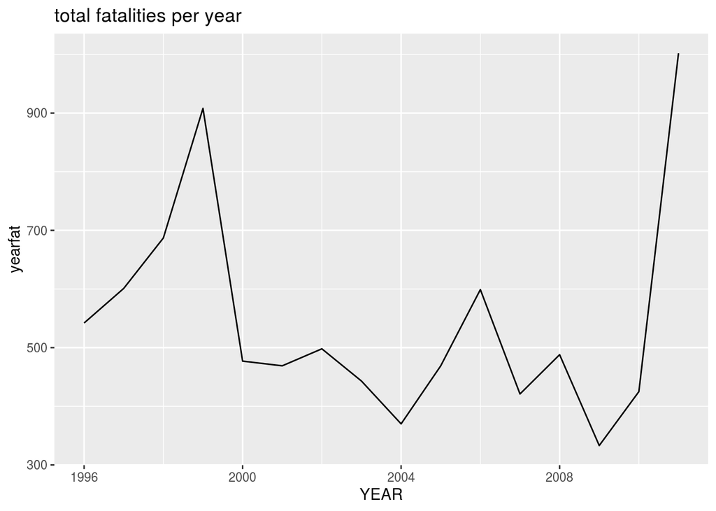

```r
library(ggplot2)
ggplot(ans2)+geom_line(aes(x=YEAR,y=yearfat))+labs(title ="total fatalities per year")
```

Total Fatalities and Injuries per event type ordered decreasinggly

```r
ans3<-DT[YEAR>1995,.(TOTFatal=sum(FATALITIES,na.rm = TRUE),TOTInjur=sum(INJURIES,na.rm = TRUE)),by=EVTYPE][order(-TOTFatal,-TOTInjur)]
ans3
```

```
##                EVTYPE TOTFatal TOTInjur
##   1:   EXCESSIVE HEAT     1797     6391
##   2:          TORNADO     1511    20667
##   3:      FLASH FLOOD      887     1674
##   4:        LIGHTNING      651     4141
##   5:            FLOOD      414     6758
##  ---
## 512:       Wintry mix        0        0
## 513: coastal flooding        0        0
## 514:    gradient wind        0        0
## 515:       small hail        0        0
## 516:    wet micoburst        0        0
```

Total Fatalities and Injuries by event type and State ordered decreasinggly

```r
ans4<-DT[YEAR>1995,.(TOTFatal=sum(FATALITIES,na.rm = TRUE),TOTInjur=sum(INJURIES,na.rm = TRUE)),by=.(EVTYPE,STATE)][order(-TOTFatal,-TOTInjur)]
ans4
```

```
##                 EVTYPE STATE TOTFatal TOTInjur
##    1:          TORNADO    AL      335     3231
##    2:   EXCESSIVE HEAT    IL      330      352
##    3:   EXCESSIVE HEAT    PA      292      320
##    4:   EXCESSIVE HEAT    TX      259       10
##    5:          TORNADO    MO      233     2059
##   ---
## 3054: coastal flooding    TX        0        0
## 3055:    gradient wind    TX        0        0
## 3056:       small hail    NY        0        0
## 3057:       small hail    VT        0        0
## 3058:    wet micoburst    OR        0        0
```

Total Fatalities and Injuries per State ordered decreasingly

```r
ans5<-DT[YEAR>1995,.(TOTFatal=sum(FATALITIES,na.rm = TRUE),TOTInjur=sum(INJURIES,na.rm = TRUE)),by=STATE][order(-TOTFatal,-TOTInjur)]
ans5
```

```
##     STATE TOTFatal TOTInjur
##  1:    TX      756     9222
##  2:    IL      586     1328
##  3:    FL      544     2884
##  4:    MO      533     5960
##  5:    CA      498     2769
##  6:    PA      492     1450
##  7:    AL      449     3707
##  8:    TN      327     2385
##  9:    NY      268      908
## 10:    NC      263     1378
## 11:    AR      228     1656
## 12:    OK      219     2375
## 13:    AZ      175      635
## 14:    GA      160     1666
```

[output cut: 57 more lines]

### which types of events have the greatest economic consequences?

Event Type frequencies per State ordered decreasingly

```r
ans6<-DT[YEAR>1995,.(.N), by = .(EVTYPE,STATE)][order(STATE,-N)]
ans6
```

```
##                         EVTYPE STATE    N
##    1:                HIGH WIND    AK 1675
##    2:                 BLIZZARD    AK  865
##    3:               HEAVY SNOW    AK  581
##    4:                    FLOOD    AK  208
##    5:             WINTER STORM    AK  143
##   ---
## 3054:               DUST DEVIL    WY    2
## 3055:        EXTREME WINDCHILL    WY    2
## 3056:             Blowing Snow    WY    1
## 3057:                ICE ROADS    WY    1
## 3058: MARINE THUNDERSTORM WIND    XX    2
```

Frequencies of event type ordered decreasingly

```r
ans7<-DT[YEAR>1995,.(.N), by = .(EVTYPE)][order(-N)]
ans7
```

```
##                 EVTYPE      N
##   1:              HAIL 207715
##   2:         TSTM WIND 128662
##   3: THUNDERSTORM WIND  81402
##   4:       FLASH FLOOD  50999
##   5:             FLOOD  24247
##  ---
## 512:     WIND AND WAVE      1
## 513:        WINTER MIX      1
## 514:               WND      1
## 515:        Wintry Mix      1
## 516:     wet micoburst      1
```

Number of events per State ordered decreasingly

```r
ans8<-DT[YEAR>1995,.(.N), by = STATE][order(-N)]
ans8
```

```
##     STATE     N
##  1:    TX 51335
##  2:    KS 38649
##  3:    OK 26980
##  4:    MO 25802
##  5:    IA 22712
##  6:    IL 21215
##  7:    NE 20955
##  8:    NC 19413
##  9:    AR 18234
## 10:    GA 18063
## 11:    KY 17683
## 12:    MN 17613
## 13:    OH 17387
## 14:    TN 17273
```

[output cut: 57 more lines]

Total property and crop damage per year with corresponding means

```r
ans9<-DT[,.(TOTprpdmg=sum(PROPDMG,na.rm = TRUE),TOTcropdmg=sum(CROPDMG,na.rm = TRUE),meanprpdmg=mean(PROPDMG,na.rm = TRUE),meancropdmg=mean(CROPDMG,na.rm = TRUE)),by=YEAR][YEAR>1995][order(YEAR)]
ans9
```

```
##     YEAR TOTprpdmg TOTcropdmg meanprpdmg meancropdmg
##  1: 1996  424503.3   69291.90  13.154736    2.147254
##  2: 1997  337999.5   74074.56  11.785200    2.582795
##  3: 1998  545844.6  102235.21  14.316110    2.681368
##  4: 1999  364611.5   62707.15  11.653026    2.004128
##  5: 2000  403471.2   79413.61  11.704657    2.303780
##  6: 2001  383596.8   48248.35  10.971820    1.380023
##  7: 2002  355741.3   49230.64   9.801927    1.356478
##  8: 2003  437754.9   52322.19  11.012147    1.316215
##  9: 2004  412837.6   72438.97  10.487961    1.840281
## 10: 2005  428309.1   48443.05  10.930714    1.236297
## 11: 2006  449583.7   65850.56  10.209921    1.495448
## 12: 2007  438170.3   76768.00  10.121977    1.773384
## 13: 2008  690246.1  183821.00  12.400448    3.302391
## 14: 2009  553432.6   59683.00  12.079197    1.302639
## 15: 2010  594847.9   59014.00  12.351237    1.225348
## 16: 2011  820290.7   98311.00  13.193469    1.581224
```

Let’s graphic the table above

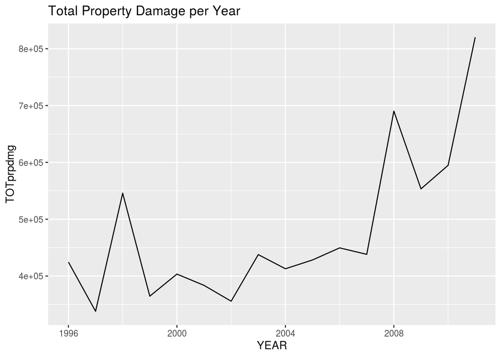

```r
ggplot(ans9)+geom_line(aes(x=YEAR,y=TOTprpdmg))+labs(title ="Total Property Damage per Year")
```

Total property and crop damages per year by State and corresponding means ordered decreasingly

```r
ans10<-DT[,.(TOTprpdmg=sum(PROPDMG,na.rm = TRUE),TOTcropdmg=sum(CROPDMG,na.rm = TRUE),meanprpdmg=mean(PROPDMG,na.rm = TRUE),meancropdmg=mean(CROPDMG,na.rm = TRUE)),by=.(YEAR,STATE)][YEAR>1995][order(YEAR,-TOTprpdmg,-TOTcropdmg)]
ans10
```

```
##       YEAR STATE TOTprpdmg TOTcropdmg meanprpdmg meancropdmg
##    1: 1996    TX  36001.07    2571.93   11.16312   0.7974977
##    2: 1996    VA  27584.27    8766.89   26.42171   8.3974042
##    3: 1996    NY  24998.46     645.00   28.56967   0.7371429
##    4: 1996    IA  19055.90    4156.60   35.09374   7.6548803
##    5: 1996    WI  18814.20    4724.10   28.63653   7.1904110
##   ---
## 1006: 2011    LE      0.00       0.00    0.00000   0.0000000
## 1007: 2011    LC      0.00       0.00    0.00000   0.0000000
## 1008: 2011    LO      0.00       0.00    0.00000   0.0000000
## 1009: 2011    XX      0.00       0.00    0.00000   0.0000000
## 1010: 2011    PH      0.00       0.00    0.00000   0.0000000
```

Total property and crop damages per by State and years with corresponding means ordered decreasingly

```r
ans11<-DT[,.(TOTprpdmg=sum(PROPDMG,na.rm = TRUE),TOTcropdmg=sum(CROPDMG,na.rm = TRUE),meanprpdmg=mean(PROPDMG,na.rm =TRUE)),by=.(STATE,YEAR)][YEAR>1995][order(STATE,YEAR,-TOTprpdmg,-TOTcropdmg)]
ans11
```

```
##       STATE YEAR TOTprpdmg TOTcropdmg meanprpdmg
##    1:    AK 1996    549.00          0   2.196000
##    2:    AK 1997    845.75          0   4.975000
##    3:    AK 1998    493.30          0   2.360287
##    4:    AK 1999   2187.00         10   7.100649
##    5:    AK 2000   2398.20          5   7.862951
##   ---
## 1006:    WY 2009   4024.00         65   7.874755
## 1007:    WY 2010   3291.40        124   4.412064
## 1008:    WY 2011   5512.00       1390   7.408602
## 1009:    XX 2009      0.00          0   0.000000
## 1010:    XX 2011      0.00          0   0.000000
```

Let’s graphic the table above

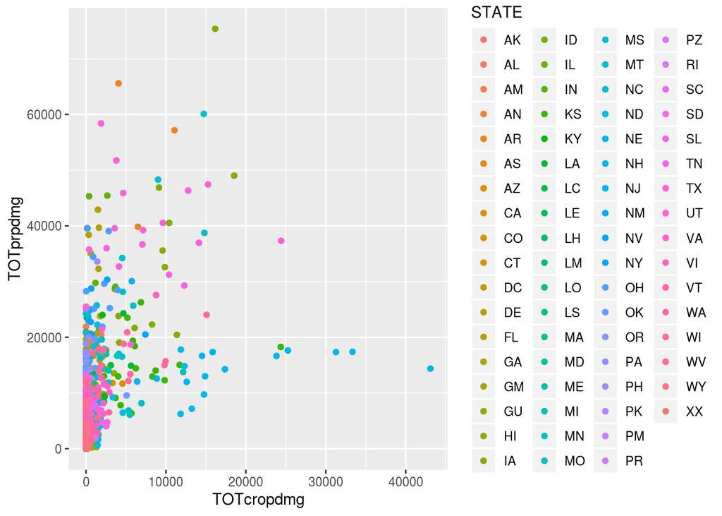

```r
qplot(TOTcropdmg,TOTprpdmg,data=ans11,color=STATE)
```

Total property and crop damages by State ordered decreasingly

```r
ans12<-DT[YEAR>1995,.(TOTprpdmg=sum(PROPDMG,na.rm = TRUE),TOTcropdmg=sum(CROPDMG,na.rm = TRUE)),by=STATE][order(-TOTprpdmg,-TOTcropdmg)]
ans12
```

```
##     STATE TOTprpdmg TOTcropdmg
##  1:    TX 627973.21  139299.84
##  2:    IA 465302.95  121546.47
##  3:    OH 398135.48   19704.65
##  4:    MS 357590.20   56017.79
##  5:    GA 354780.71    6890.26
##  6:    NY 271327.28   18236.55
##  7:    AL 255756.45    7479.54
##  8:    IL 254046.49   11732.02
##  9:    AR 241738.20   25648.13
## 10:    FL 239133.89    9749.38
## 11:    KS 232477.48  113334.87
## 12:    NE 228885.95  288522.79
## 13:    PA 225617.46    3448.90
## 14:    WI 213111.63   69215.00
```

[output cut: 57 more lines]

Total property and crop damages by event type ordered decreasingly

```r
ans13<-DT[YEAR>1995,.(TOTprpdmg=sum(PROPDMG,na.rm = TRUE),TOTcropdmg=sum(CROPDMG,na.rm = TRUE)),by=EVTYPE][order(-TOTprpdmg,-TOTcropdmg)]
ans13
```

```
##                 EVTYPE TOTprpdmg TOTcropdmg
##   1:         TSTM WIND 1330706.9   109110.6
##   2:       FLASH FLOOD 1247562.5   161066.7
##   3:           TORNADO 1187878.2    90128.5
##   4: THUNDERSTORM WIND  862257.4    66663.0
##   5:             FLOOD  824936.7   151826.2
##  ---
## 512:    Winter Weather       0.0        0.0
## 513:        Wintry mix       0.0        0.0
## 514:  coastal flooding       0.0        0.0
## 515:        small hail       0.0        0.0
## 516:     wet micoburst       0.0        0.0
```

Total economic damage by year

```r
ans14<-DT[,.(TOTEconomicDMG=sum(PROPDMG+CROPDMG)),by=YEAR][YEAR>1995][order(YEAR)]
ans14
```

```
##     YEAR TOTEconomicDMG
##  1: 1996       493795.2
##  2: 1997       412074.1
##  3: 1998       648079.9
##  4: 1999       427318.7
##  5: 2000       482884.8
##  6: 2001       431845.1
##  7: 2002       404972.0
##  8: 2003       490077.0
##  9: 2004       485276.6
## 10: 2005       476752.2
## 11: 2006       515434.2
## 12: 2007       514938.3
## 13: 2008       874067.1
## 14: 2009       613115.6
## 15: 2010       653861.9
## 16: 2011       918601.7
```

Total economic damage by State ordered decreasingly

```r
ans15<-DT[YEAR>1995,.(TOTEconomicDMG=sum(PROPDMG+CROPDMG)),by=.(STATE)][order(-TOTEconomicDMG)]
ans15
```

```
##     STATE TOTEconomicDMG
##  1:    TX      767273.05
##  2:    IA      586849.42
##  3:    NE      517408.74
##  4:    OH      417840.13
##  5:    MS      413607.99
##  6:    GA      361670.97
##  7:    KS      345812.35
##  8:    NY      289563.83
##  9:    WI      282326.63
## 10:    AR      267386.33
## 11:    IL      265778.51
## 12:    AL      263235.99
## 13:    FL      248883.27
## 14:    PA      229066.36
```

[output cut: 57 more lines]

Total economic damage by event type

```r
ans16<-DT[YEAR>1995,.(TOTEconomicDMG=sum(PROPDMG+CROPDMG)),by=EVTYPE][order(-TOTEconomicDMG)]
ans16
```

```
##                EVTYPE TOTEconomicDMG
##   1:        TSTM WIND      1439817.5
##   2:      FLASH FLOOD      1408629.2
##   3:          TORNADO      1278006.7
##   4:             HAIL      1073656.4
##   5:            FLOOD       976762.9
##  ---
## 512:   Winter Weather            0.0
## 513:       Wintry mix            0.0
## 514: coastal flooding            0.0
## 515:       small hail            0.0
## 516:    wet micoburst            0.0
```

### Results

Across the United States, which types of events (as indicated in the EVTYPE variable) are most harmful with respect to population health? The most harmful events across USA for population health considering fatalities and injuries related are:

```
##             EVTYPE TOTFatal TOTInjur
##  1: EXCESSIVE HEAT     1797     6391
##  2:        TORNADO     1511    20667
##  3:    FLASH FLOOD      887     1674
##  4:      LIGHTNING      651     4141
##  5:          FLOOD      414     6758
##  6:    RIP CURRENT      340      209
##  7:      TSTM WIND      241     3629
##  8:           HEAT      237     1222
##  9:      HIGH WIND      235     1083
## 10:      AVALANCHE      223      156
```

Across the United States, which types of events have the greatest economic consequences? The events across USA with the greatest economic consequences considering property damage and crops damage are:

```
##                EVTYPE  TOTprpdmg TOTcropdmg
##  1:         TSTM WIND 1330706.91  109110.60
##  2:       FLASH FLOOD 1247562.54  161066.71
##  3:           TORNADO 1187878.23   90128.50
##  4: THUNDERSTORM WIND  862257.36   66663.00
##  5:             FLOOD  824936.71  151826.18
##  6:              HAIL  575317.28  498339.12
##  7:         LIGHTNING  488561.85    1903.44
##  8:         HIGH WIND  315098.06   17268.21
##  9:      WINTER STORM  126910.49    1963.99
## 10:        HEAVY SNOW   89393.11    1591.70
```

The event types causing more fatalities and injuries are:

```
##             EVTYPE TOTFatal TOTInjur
##  1: EXCESSIVE HEAT     1797     6391
##  2:        TORNADO     1511    20667
##  3:    FLASH FLOOD      887     1674
##  4:      LIGHTNING      651     4141
##  5:          FLOOD      414     6758
##  6:    RIP CURRENT      340      209
##  7:      TSTM WIND      241     3629
##  8:           HEAT      237     1222
##  9:      HIGH WIND      235     1083
## 10:      AVALANCHE      223      156
```

The Event Types most frequent are:

```
##                EVTYPE      N
##  1:              HAIL 207715
##  2:         TSTM WIND 128662
##  3: THUNDERSTORM WIND  81402
##  4:       FLASH FLOOD  50999
##  5:             FLOOD  24247
##  6:           TORNADO  23154
##  7:         HIGH WIND  19907
##  8:        HEAVY SNOW  14000
##  9:         LIGHTNING  13203
## 10:        HEAVY RAIN  11509
```

The States with more events are:

```
##     STATE     N
##  1:    TX 51335
##  2:    KS 38649
##  3:    OK 26980
##  4:    MO 25802
##  5:    IA 22712
##  6:    IL 21215
##  7:    NE 20955
##  8:    NC 19413
##  9:    AR 18234
## 10:    GA 18063
```

The States with more economic damage are:

```
##     STATE TOTEconomicDMG
##  1:    TX       767273.1
##  2:    IA       586849.4
##  3:    NE       517408.7
##  4:    OH       417840.1
##  5:    MS       413608.0
##  6:    GA       361671.0
##  7:    KS       345812.3
##  8:    NY       289563.8
##  9:    WI       282326.6
## 10:    AR       267386.3
## 11:    IL       265778.5
## 12:    AL       263236.0
## 13:    FL       248883.3
## 14:    PA       229066.4
## 15:    TN       223129.9
```

The events types with more total economic damage are:

```
##                EVTYPE TOTEconomicDMG
##  1:         TSTM WIND     1439817.51
##  2:       FLASH FLOOD     1408629.25
##  3:           TORNADO     1278006.73
##  4:              HAIL     1073656.40
##  5:             FLOOD      976762.89
##  6: THUNDERSTORM WIND      928920.36
##  7:         LIGHTNING      490465.29
##  8:         HIGH WIND      332366.27
##  9:      WINTER STORM      128874.48
## 10:        HEAVY SNOW       90984.81
```

### Apendix

Since the data size is to big for handling we will use Caret package to slice the sample data smaller for some linear regression models

```r
library(caret)
```

```r
# create training and test sets
inTrain <- createDataPartition(y=DT$FATALITIES,p=0.1, list=FALSE)
training<- DT[inTrain,]
testing<- DT[-inTrain,]
```

```r
dim(training)
```

```
## [1] 90230    13
```

```r
dim(testing)
```

```
## [1] 812067     13
```

Some linear regression models are shown for statistical inference

```r
lm1<-lm(FATALITIES~as.factor(EVTYPE),data =training)
```

```r
summary(lm1)
```

```
##
## Call:
## lm(formula = FATALITIES ~ as.factor(EVTYPE), data = training)
##
## Residuals:
##    Min     1Q Median     3Q    Max
## -1.043 -0.011 -0.002  0.000 89.906
##
## Coefficients:
##                                                   Estimate Std. Error
## (Intercept)                                     -2.606e-10  4.304e-01
## as.factor(EVTYPE)ACCUMULATED SNOWFALL            2.606e-10  5.271e-01
## as.factor(EVTYPE)AGRICULTURAL FREEZE             2.606e-10  5.271e-01
## as.factor(EVTYPE)ASTRONOMICAL HIGH TIDE          2.607e-10  4.537e-01
## as.factor(EVTYPE)ASTRONOMICAL LOW TIDE           2.606e-10  4.445e-01
## as.factor(EVTYPE)AVALANCHE                       9.429e-01  4.365e-01
## as.factor(EVTYPE)BEACH EROSION                   2.607e-10  6.087e-01
## as.factor(EVTYPE)BITTER WIND CHILL TEMPERATURES  2.606e-10  6.087e-01
## as.factor(EVTYPE)BLACK ICE                       2.607e-10  4.812e-01
## as.factor(EVTYPE)BLIZZARD                        2.583e-02  4.312e-01
## as.factor(EVTYPE)BLIZZARD AND EXTREME WIND CHIL  2.607e-10  6.087e-01
## as.factor(EVTYPE)BLOWING DUST                    2.606e-10  6.087e-01
## as.factor(EVTYPE)BLOWING SNOW                    2.607e-10  6.087e-01
## as.factor(EVTYPE)BLOWING SNOW- EXTREME WIND CHI  2.606e-10  6.087e-01
## as.factor(EVTYPE)Black Ice                       2.607e-10  5.271e-01
## as.factor(EVTYPE)COASTAL FLOOD                   2.606e-10  4.337e-01
## as.factor(EVTYPE)COASTAL FLOODING                2.606e-10  4.601e-01
## as.factor(EVTYPE)COLD                            5.000e-01  5.271e-01
## as.factor(EVTYPE)COLD AIR FUNNEL                 2.607e-10  6.087e-01
## as.factor(EVTYPE)COLD AIR FUNNELS                2.607e-10  6.087e-01
## as.factor(EVTYPE)COLD WAVE                       3.000e+00  6.087e-01
## as.factor(EVTYPE)COLD WEATHER                    1.000e+00  6.087e-01
## as.factor(EVTYPE)COLD WIND CHILL TEMPERATURES    2.606e-10  4.970e-01
## as.factor(EVTYPE)COLD/WIND CHILL                 2.203e-01  4.340e-01
## as.factor(EVTYPE)Coastal Flooding                2.607e-10  6.087e-01
## as.factor(EVTYPE)Cold and Frost                  2.606e-10  6.087e-01
## as.factor(EVTYPE)DAMAGING FREEZE                 2.607e-10  6.087e-01
## as.factor(EVTYPE)DENSE FOG                       2.608e-10  4.323e-01
## as.factor(EVTYPE)DENSE SMOKE                     2.607e-10  4.812e-01
## as.factor(EVTYPE)DROUGHT                         2.604e-10  4.313e-01
```

[output cut: 560 more lines]

```
## as.factor(EVTYPE)WINTER STORMS                    0.000  1.00000
## as.factor(EVTYPE)WINTER WEATHER                   0.026  0.97898
## as.factor(EVTYPE)WINTER WEATHER MIX               0.000  1.00000
## as.factor(EVTYPE)WINTER WEATHER/MIX               0.051  0.95905
## as.factor(EVTYPE)WINTERY MIX                      0.000  1.00000
## as.factor(EVTYPE)WINTRY MIX                       0.000  1.00000
## as.factor(EVTYPE)Wind Damage                      0.000  1.00000
## as.factor(EVTYPE)Winter Weather                   0.000  1.00000
## as.factor(EVTYPE)blowing snow                     1.643  0.10041
## ---
## Signif. codes:  0 '***' 0.001 '**' 0.01 '*' 0.05 '.' 0.1 ' ' 1
##
## Residual standard error: 0.4304 on 89931 degrees of freedom
## Multiple R-squared:  0.0218, Adjusted R-squared:  0.01856
## F-statistic: 6.724 on 298 and 89931 DF,  p-value: < 2.2e-16
```

```r
lm2<-lm(INJURIES~as.factor(EVTYPE),data = training)
```

```r
summary(lm2)
```

```
##
## Call:
## lm(formula = INJURIES ~ as.factor(EVTYPE), data = training)
##
## Residuals:
##     Min      1Q  Median      3Q     Max
##  -40.00   -0.04   -0.03    0.00 1226.49
##
## Coefficients:
##                                                   Estimate Std. Error
## (Intercept)                                      3.106e-10  5.252e+00
## as.factor(EVTYPE)ACCUMULATED SNOWFALL           -3.122e-10  6.432e+00
## as.factor(EVTYPE)AGRICULTURAL FREEZE            -3.103e-10  6.432e+00
## as.factor(EVTYPE)ASTRONOMICAL HIGH TIDE         -3.111e-10  5.536e+00
## as.factor(EVTYPE)ASTRONOMICAL LOW TIDE          -3.114e-10  5.424e+00
## as.factor(EVTYPE)AVALANCHE                       4.000e-01  5.326e+00
## as.factor(EVTYPE)BEACH EROSION                  -3.102e-10  7.427e+00
## as.factor(EVTYPE)BITTER WIND CHILL TEMPERATURES -3.103e-10  7.427e+00
## as.factor(EVTYPE)BLACK ICE                      -3.104e-10  5.871e+00
## as.factor(EVTYPE)BLIZZARD                        6.642e-02  5.261e+00
## as.factor(EVTYPE)BLIZZARD AND EXTREME WIND CHIL -3.105e-10  7.427e+00
## as.factor(EVTYPE)BLOWING DUST                   -3.103e-10  7.427e+00
## as.factor(EVTYPE)BLOWING SNOW                   -3.113e-10  7.427e+00
## as.factor(EVTYPE)BLOWING SNOW- EXTREME WIND CHI -3.106e-10  7.427e+00
## as.factor(EVTYPE)Black Ice                      -3.095e-10  6.432e+00
## as.factor(EVTYPE)COASTAL FLOOD                   1.538e-02  5.292e+00
## as.factor(EVTYPE)COASTAL FLOODING               -3.108e-10  5.614e+00
## as.factor(EVTYPE)COLD                           -3.108e-10  6.432e+00
## as.factor(EVTYPE)COLD AIR FUNNEL                -3.104e-10  7.427e+00
## as.factor(EVTYPE)COLD AIR FUNNELS               -3.110e-10  7.427e+00
## as.factor(EVTYPE)COLD WAVE                      -3.113e-10  7.427e+00
## as.factor(EVTYPE)COLD WEATHER                   -3.104e-10  7.427e+00
## as.factor(EVTYPE)COLD WIND CHILL TEMPERATURES   -3.109e-10  6.064e+00
## as.factor(EVTYPE)COLD/WIND CHILL                -3.098e-10  5.296e+00
## as.factor(EVTYPE)Coastal Flooding               -3.111e-10  7.427e+00
## as.factor(EVTYPE)Cold and Frost                 -3.108e-10  7.427e+00
## as.factor(EVTYPE)DAMAGING FREEZE                -3.098e-10  7.427e+00
## as.factor(EVTYPE)DENSE FOG                       2.703e-02  5.275e+00
## as.factor(EVTYPE)DENSE SMOKE                    -3.097e-10  5.871e+00
## as.factor(EVTYPE)DROUGHT                        -3.098e-10  5.262e+00
```

[output cut: 560 more lines]

```
## as.factor(EVTYPE)WINTER STORMS                    0.000    1.000
## as.factor(EVTYPE)WINTER WEATHER                   0.012    0.991
## as.factor(EVTYPE)WINTER WEATHER MIX               0.404    0.686
## as.factor(EVTYPE)WINTER WEATHER/MIX               0.006    0.995
## as.factor(EVTYPE)WINTERY MIX                      0.000    1.000
## as.factor(EVTYPE)WINTRY MIX                       0.000    1.000
## as.factor(EVTYPE)Wind Damage                      0.000    1.000
## as.factor(EVTYPE)Winter Weather                   0.000    1.000
## as.factor(EVTYPE)blowing snow                     0.135    0.893
## ---
## Signif. codes:  0 '***' 0.001 '**' 0.01 '*' 0.05 '.' 0.1 ' ' 1
##
## Residual standard error: 5.252 on 89931 degrees of freedom
## Multiple R-squared:  0.007531,   Adjusted R-squared:  0.004242
## F-statistic:  2.29 on 298 and 89931 DF,  p-value: < 2.2e-16
```

```r
lm3<-lm(FATALITIES~as.factor(EVTYPE)+PROPDMG+as.factor(STATE),data=training)
```

```r
summary(lm3)
```

```
##
## Call:
## lm(formula = FATALITIES ~ as.factor(EVTYPE) + PROPDMG + as.factor(STATE),
##     data = training)
##
## Residuals:
##    Min     1Q Median     3Q    Max
## -1.070 -0.011 -0.001  0.005 89.731
##
## Coefficients:
##                                                   Estimate Std. Error
## (Intercept)                                      1.638e-03  4.309e-01
## as.factor(EVTYPE)ACCUMULATED SNOWFALL           -7.078e-03  5.272e-01
## as.factor(EVTYPE)AGRICULTURAL FREEZE             2.284e-03  5.271e-01
## as.factor(EVTYPE)ASTRONOMICAL HIGH TIDE          1.017e-03  4.537e-01
## as.factor(EVTYPE)ASTRONOMICAL LOW TIDE           1.841e-03  4.445e-01
## as.factor(EVTYPE)AVALANCHE                       9.345e-01  4.364e-01
## as.factor(EVTYPE)BEACH EROSION                  -6.286e-03  6.085e-01
## as.factor(EVTYPE)BITTER WIND CHILL TEMPERATURES  1.239e-03  6.088e-01
## as.factor(EVTYPE)BLACK ICE                      -1.434e-02  4.811e-01
## as.factor(EVTYPE)BLIZZARD                        2.334e-02  4.311e-01
## as.factor(EVTYPE)BLIZZARD AND EXTREME WIND CHIL -2.306e-04  6.085e-01
## as.factor(EVTYPE)BLOWING DUST                   -2.365e-03  6.086e-01
## as.factor(EVTYPE)BLOWING SNOW                   -6.364e-04  6.085e-01
## as.factor(EVTYPE)BLOWING SNOW- EXTREME WIND CHI  3.205e-03  6.085e-01
## as.factor(EVTYPE)Black Ice                      -4.757e-03  5.270e-01
## as.factor(EVTYPE)COASTAL FLOOD                  -2.060e-02  4.336e-01
## as.factor(EVTYPE)COASTAL FLOODING               -2.596e-02  4.601e-01
## as.factor(EVTYPE)COLD                            4.889e-01  5.271e-01
## as.factor(EVTYPE)COLD AIR FUNNEL                 3.205e-03  6.085e-01
## as.factor(EVTYPE)COLD AIR FUNNELS               -1.145e-02  6.085e-01
## as.factor(EVTYPE)COLD WAVE                       2.989e+00  6.085e-01
## as.factor(EVTYPE)COLD WEATHER                    9.951e-01  6.085e-01
## as.factor(EVTYPE)COLD WIND CHILL TEMPERATURES   -4.306e-03  4.971e-01
## as.factor(EVTYPE)COLD/WIND CHILL                 2.175e-01  4.339e-01
## as.factor(EVTYPE)Coastal Flooding               -6.286e-03  6.085e-01
## as.factor(EVTYPE)Cold and Frost                 -2.289e-03  6.085e-01
## as.factor(EVTYPE)DAMAGING FREEZE                 6.925e-03  6.085e-01
## as.factor(EVTYPE)DENSE FOG                      -3.419e-03  4.322e-01
## as.factor(EVTYPE)DENSE SMOKE                    -1.429e-03  4.811e-01
```

[output cut: 695 more lines]

```
## as.factor(STATE)TX                               -0.056  0.95510
## as.factor(STATE)UT                                0.672  0.50140
## as.factor(STATE)VA                                0.027  0.97848
## as.factor(STATE)VI                                0.496  0.61969
## as.factor(STATE)VT                                0.027  0.97811
## as.factor(STATE)WA                                0.562  0.57409
## as.factor(STATE)WI                               -0.119  0.90519
## as.factor(STATE)WV                               -0.079  0.93740
## as.factor(STATE)WY                               -0.339  0.73476
## ---
## Signif. codes:  0 '***' 0.001 '**' 0.01 '*' 0.05 '.' 0.1 ' ' 1
##
## Residual standard error: 0.4302 on 89864 degrees of freedom
## Multiple R-squared:  0.02344,    Adjusted R-squared:  0.01947
## F-statistic: 5.909 on 365 and 89864 DF,  p-value: < 2.2e-16
```

```r
lm4<-update(lm3,FATALITIES~as.factor(EVTYPE)+PROPDMG+as.factor(STATE)+as.factor(F)+as.factor(MAG))
```

```r
summary(lm4)
```

```
##
## Call:
## lm(formula = FATALITIES ~ as.factor(EVTYPE) + PROPDMG + as.factor(STATE) +
##     as.factor(F) + as.factor(MAG), data = training)
##
## Residuals:
##    Min     1Q Median     3Q    Max
## -6.062 -0.009  0.000  0.003 87.557
##
## Coefficients:
##                                                   Estimate Std. Error
## (Intercept)                                     -9.077e-04  4.174e-01
## as.factor(EVTYPE)ACCUMULATED SNOWFALL           -5.795e-03  5.107e-01
## as.factor(EVTYPE)AGRICULTURAL FREEZE             3.201e-03  5.105e-01
## as.factor(EVTYPE)ASTRONOMICAL HIGH TIDE          2.992e-03  4.394e-01
## as.factor(EVTYPE)ASTRONOMICAL LOW TIDE           3.631e-03  4.305e-01
## as.factor(EVTYPE)AVALANCHE                       9.348e-01  4.228e-01
## as.factor(EVTYPE)BEACH EROSION                  -2.722e-03  5.894e-01
## as.factor(EVTYPE)BITTER WIND CHILL TEMPERATURES  3.222e-03  5.897e-01
## as.factor(EVTYPE)BLACK ICE                      -1.096e-02  4.660e-01
## as.factor(EVTYPE)BLIZZARD                        2.587e-02  4.176e-01
## as.factor(EVTYPE)BLIZZARD AND EXTREME WIND CHIL  8.894e-04  5.894e-01
## as.factor(EVTYPE)BLOWING DUST                   -3.483e-03  5.895e-01
## as.factor(EVTYPE)BLOWING SNOW                    1.272e-03  5.894e-01
## as.factor(EVTYPE)BLOWING SNOW- EXTREME WIND CHI  9.825e-03  5.894e-01
## as.factor(EVTYPE)Black Ice                      -2.430e-03  5.105e-01
## as.factor(EVTYPE)COASTAL FLOOD                  -1.839e-02  4.200e-01
## as.factor(EVTYPE)COASTAL FLOODING               -2.096e-02  4.457e-01
## as.factor(EVTYPE)COLD                            4.901e-01  5.106e-01
## as.factor(EVTYPE)COLD AIR FUNNEL                 9.825e-03  5.894e-01
## as.factor(EVTYPE)COLD AIR FUNNELS               -5.251e-03  5.894e-01
## as.factor(EVTYPE)COLD WAVE                       2.995e+00  5.894e-01
## as.factor(EVTYPE)COLD WEATHER                    9.949e-01  5.894e-01
## as.factor(EVTYPE)COLD WIND CHILL TEMPERATURES   -2.790e-03  4.815e-01
## as.factor(EVTYPE)COLD/WIND CHILL                 2.205e-01  4.203e-01
## as.factor(EVTYPE)Coastal Flooding               -2.722e-03  5.894e-01
## as.factor(EVTYPE)Cold and Frost                 -3.922e-04  5.894e-01
## as.factor(EVTYPE)DAMAGING FREEZE                 7.848e-03  5.894e-01
## as.factor(EVTYPE)DENSE FOG                      -5.046e-04  4.187e-01
## as.factor(EVTYPE)DENSE SMOKE                     6.013e-04  4.660e-01
```

[output cut: 965 more lines]

```
## as.factor(MAG)91.00                               0.921 0.356947
## as.factor(MAG)92.00                               1.275 0.202212
## as.factor(MAG)93.00                              -0.022 0.982147
## as.factor(MAG)94.00                              -0.022 0.982269
## as.factor(MAG)95.00                               0.753 0.451209
## as.factor(MAG)96.00                               0.029 0.976945
## as.factor(MAG)97.00                              -0.041 0.967382
## as.factor(MAG)98.00                               0.006 0.995260
## as.factor(MAG)99.00                              -0.010 0.991862
## ---
## Signif. codes:  0 '***' 0.001 '**' 0.01 '*' 0.05 '.' 0.1 ' ' 1
##
## Residual standard error: 0.4167 on 89729 degrees of freedom
## Multiple R-squared:  0.08515,    Adjusted R-squared:  0.08005
## F-statistic:  16.7 on 500 and 89729 DF,  p-value: < 2.2e-16
```

The anova analysis shows wich variables improve the prediction model for Prob>(F) lower than 0.05

```r
anova(lm1,lm3,lm4)
```

```
## Analysis of Variance Table
##
## Model 1: FATALITIES ~ as.factor(EVTYPE)
## Model 2: FATALITIES ~ as.factor(EVTYPE) + PROPDMG + as.factor(STATE)
## Model 3: FATALITIES ~ as.factor(EVTYPE) + PROPDMG + as.factor(STATE) +
##     as.factor(F) + as.factor(MAG)
##   Res.Df   RSS  Df Sum of Sq       F    Pr(>F)
## 1  89931 16659
## 2  89864 16631  67     27.97  2.4039 1.052e-09 ***
## 3  89729 15580 135   1050.93 44.8333 < 2.2e-16 ***
## ---
## Signif. codes:  0 '***' 0.001 '**' 0.01 '*' 0.05 '.' 0.1 ' ' 1
```

PCA analysis

```r
Train2<-prcomp(training[,-c("BGN_DATE","STATE","EVTYPE","F","MAG")],tol=0.04,retx = TRUE,center = TRUE,scale.=TRUE)
summary(Train2)
```

```
## Importance of components:
##                           PC1    PC2    PC3    PC4    PC5    PC6     PC7
## Standard deviation     1.4101 1.1861 1.0485 0.9989 0.9610 0.9168 0.74508
## Proportion of Variance 0.2485 0.1758 0.1374 0.1247 0.1154 0.1051 0.06939
## Cumulative Proportion  0.2485 0.4244 0.5618 0.6865 0.8020 0.9070 0.97642
##                            PC8
## Standard deviation     0.43429
## Proportion of Variance 0.02358
## Cumulative Proportion  1.00000
```

```r
lm5<-lm(PROPDMG~as.factor(EVTYPE),data = training)
```

```r
summary(lm5)
```

```
##
## Call:
## lm(formula = PROPDMG ~ as.factor(EVTYPE), data = training)
##
## Residuals:
##     Min      1Q  Median      3Q     Max
## -250.00   -9.90   -4.42   -2.21  968.97
##
## Coefficients:
##                                                   Estimate Std. Error
## (Intercept)                                     -3.732e-09  5.571e+01
## as.factor(EVTYPE)ACCUMULATED SNOWFALL            3.755e-09  6.823e+01
## as.factor(EVTYPE)AGRICULTURAL FREEZE             3.700e-09  6.823e+01
## as.factor(EVTYPE)ASTRONOMICAL HIGH TIDE          2.778e+00  5.872e+01
## as.factor(EVTYPE)ASTRONOMICAL LOW TIDE           3.715e-09  5.754e+01
## as.factor(EVTYPE)AVALANCHE                       9.286e+00  5.650e+01
## as.factor(EVTYPE)BEACH EROSION                   3.726e-09  7.879e+01
## as.factor(EVTYPE)BITTER WIND CHILL TEMPERATURES  3.777e-09  7.879e+01
## as.factor(EVTYPE)BLACK ICE                       3.742e-09  6.229e+01
## as.factor(EVTYPE)BLIZZARD                        3.858e+00  5.581e+01
## as.factor(EVTYPE)BLIZZARD AND EXTREME WIND CHIL  3.705e-09  7.879e+01
## as.factor(EVTYPE)BLOWING DUST                    3.781e-09  7.879e+01
## as.factor(EVTYPE)BLOWING SNOW                    3.771e-09  7.879e+01
## as.factor(EVTYPE)BLOWING SNOW- EXTREME WIND CHI  3.815e-09  7.879e+01
## as.factor(EVTYPE)Black Ice                       3.702e-09  6.823e+01
## as.factor(EVTYPE)COASTAL FLOOD                   5.695e+00  5.614e+01
## as.factor(EVTYPE)COASTAL FLOODING                7.857e+01  5.956e+01
## as.factor(EVTYPE)COLD                            3.745e-09  6.823e+01
## as.factor(EVTYPE)COLD AIR FUNNEL                 3.680e-09  7.879e+01
## as.factor(EVTYPE)COLD AIR FUNNELS                3.765e-09  7.879e+01
## as.factor(EVTYPE)COLD WAVE                       3.776e-09  7.879e+01
## as.factor(EVTYPE)COLD WEATHER                    3.681e-09  7.879e+01
## as.factor(EVTYPE)COLD WIND CHILL TEMPERATURES    3.706e-09  6.433e+01
## as.factor(EVTYPE)COLD/WIND CHILL                 1.695e-02  5.618e+01
## as.factor(EVTYPE)Coastal Flooding                3.787e-09  7.879e+01
## as.factor(EVTYPE)Cold and Frost                  3.769e-09  7.879e+01
## as.factor(EVTYPE)DAMAGING FREEZE                 3.774e-09  7.879e+01
## as.factor(EVTYPE)DENSE FOG                       4.054e-01  5.596e+01
## as.factor(EVTYPE)DENSE SMOKE                     2.500e+01  6.229e+01
## as.factor(EVTYPE)DROUGHT                         4.060e+00  5.582e+01
```

[output cut: 560 more lines]

```
## as.factor(EVTYPE)WINTER STORMS                    0.000 1.000000
## as.factor(EVTYPE)WINTER WEATHER                   0.027 0.978190
## as.factor(EVTYPE)WINTER WEATHER MIX               0.762 0.446332
## as.factor(EVTYPE)WINTER WEATHER/MIX               0.079 0.937080
## as.factor(EVTYPE)WINTERY MIX                      0.000 1.000000
## as.factor(EVTYPE)WINTRY MIX                       0.000 1.000000
## as.factor(EVTYPE)Wind Damage                      0.000 1.000000
## as.factor(EVTYPE)Winter Weather                   0.000 1.000000
## as.factor(EVTYPE)blowing snow                     0.190 0.849006
## ---
## Signif. codes:  0 '***' 0.001 '**' 0.01 '*' 0.05 '.' 0.1 ' ' 1
##
## Residual standard error: 55.71 on 89931 degrees of freedom
## Multiple R-squared:  0.07518,    Adjusted R-squared:  0.07211
## F-statistic: 24.53 on 298 and 89931 DF,  p-value: < 2.2e-16
```